# Chapter 2

```r
library(fpp2)
```

1. Use the help menu to explore what the series gold, woolyrnq and gas represent. These are available in the forecast package.

```r
# See the structures of datas
str(gold)
```

```
##  Time-Series [1:1108] from 1 to 1108: 306 300 303 297 304 ...
```

```r
str(woolyrnq)
```

```
##  Time-Series [1:119] from 1965 to 1994: 6172 6709 6633 6660 6786 ...
```

```r
str(gas)
```

```
##  Time-Series [1:476] from 1956 to 1996: 1709 1646 1794 1878 2173 ...
```

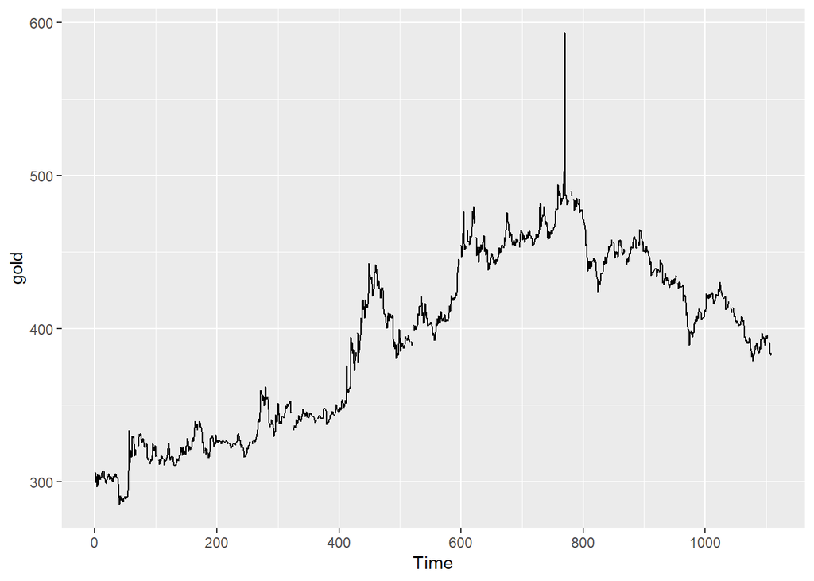

```r
# a. Use autoplot to plot each of these in separate plots.
autoplot(gold)
```

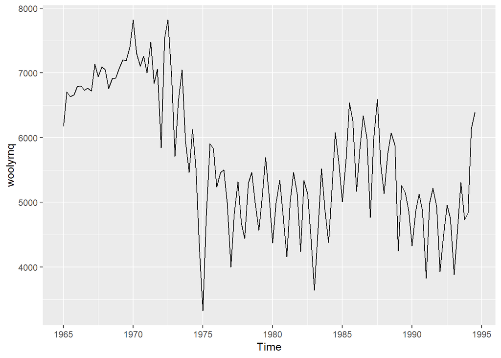

```r
autoplot(woolyrnq)
```

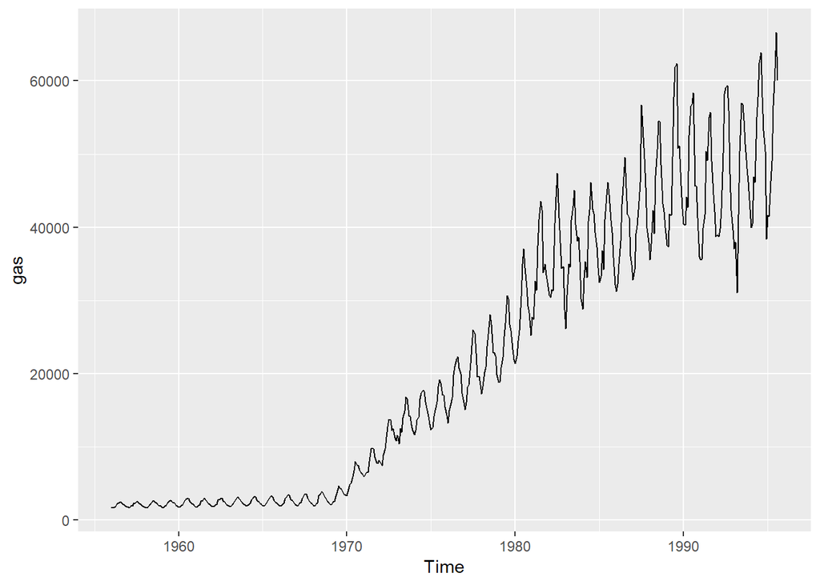

```r
autoplot(gas)
```

```r
writeLines("")
```

```r
# b. What is the frequency of each commodity series? Hint: apply the frequency() function.
print("Frequency")
```

```
## [1] "Frequency"
```

```r
print("gold")
```

```
## [1] "gold"
```

```r
frequency(gold)
```

```
## [1] 1
```

```r
print("woolyrnq")
```

```
## [1] "woolyrnq"
```

```r
frequency(woolyrnq)
```

```
## [1] 4
```

```r
print("gas")
```

```
## [1] "gas"
```

```r
frequency(gas)
```

```
## [1] 12
```

```r
writeLines("")
```

```r
# c. Use which.max() to spot the outlier in the gold series. Which observation was it?
print("When gold got maximum value?")
```

```
## [1] "When gold got maximum value?"
```

```r
which.max(gold)
```

```
## [1] 770
```

```r
print("What was the gold's maximum value?")
```

```
## [1] "What was the gold's maximum value?"
```

```r
gold[which.max(gold)]
```

```
## [1] 593.7
```

2. Download the file tute1.csv from OTexts.org/fpp2/extrafiles/tute1.csv, open it in Excel (or some other spreadsheet application), and review its contents. You should find four columns of information. Columns B through D each contain a quarterly series, labelled Sales, AdBudget and GDP. Sales contains the quarterly sales for a small company over the period 1981-2005. AdBudget is the advertising budget and GDP is the gross domestic product. All series have been adjusted for inflation.

```r
# a. You can read the data into R with the following script:
tute1 <- read.csv("tute1.csv", header=TRUE)
View(tute1)
```

```r
# b. Convert the data to time series
mytimeseries <- ts(tute1[,-1], start=1981, frequency=4)
# (The [,-1] removes the first column which contains the quarters as we don't need them now.)
```

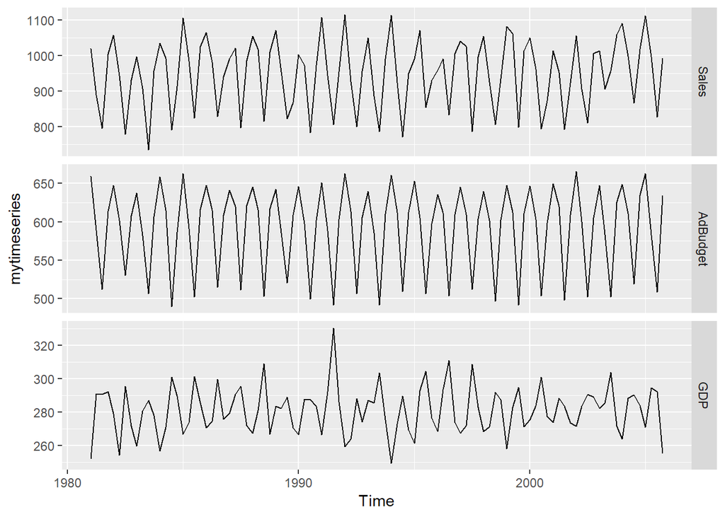

```r
# c. Construct time series plots of each of the three series
 autoplot(mytimeseries, facets=TRUE)
```

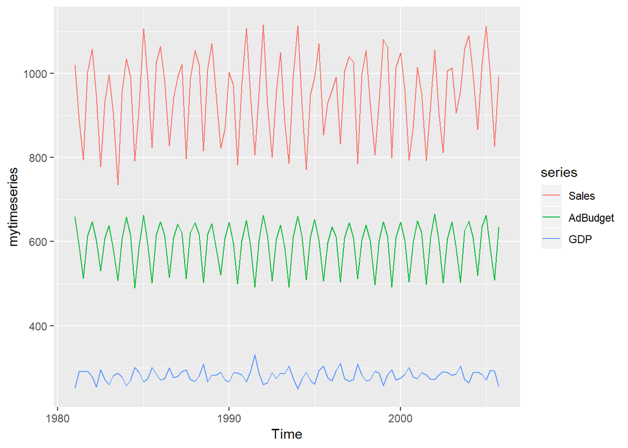

```r
# Check what happens when you don't include facets=TRUE.
autoplot(mytimeseries)
```

3. Download some monthly Australian retail data from the book website. These represent retail sales in various categories for different Australian states, and are stored in a MS-Excel file.

```r
# a. You can read the data into R with the following script:
retaildata <- readxl::read_excel("retail.xlsx", skip=1)
View(retaildata)
# The second argument (skip=1) is required because the Excel sheet has two header rows.
```

```r
# b. Select one of the time series as follows (but replace the column name with your own chosen column):
View(retaildata)
myts <- ts(retaildata[,"A3349873A"], frequency=12, start=c(1982,4))
View(retaildata)
```

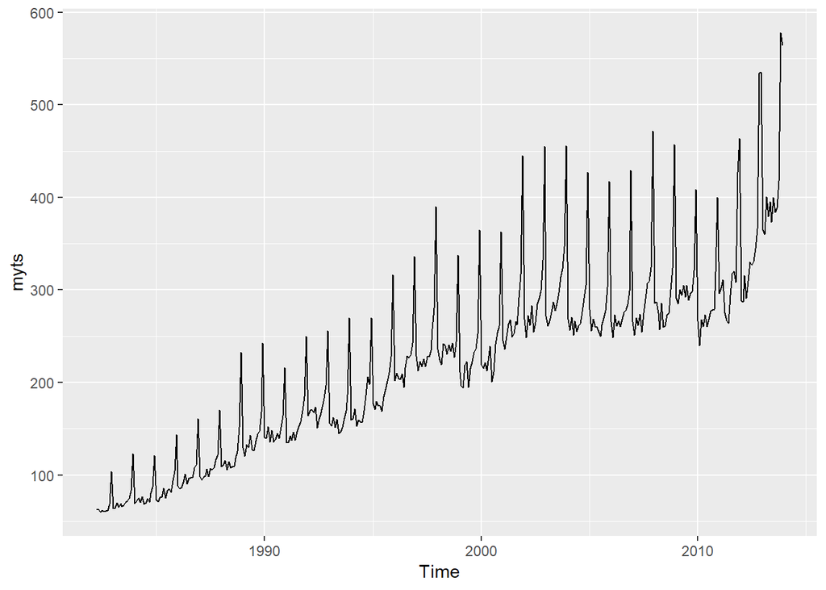

```r
# c. Explore your chosen retail time series using the following functions: autoplot, ggseasonplot, ggsubseriesplot, gglagplot, ggAcf
#Can you spot any seasonality, cyclicity and trend? What do you learn about the series?
autoplot(myts)
```

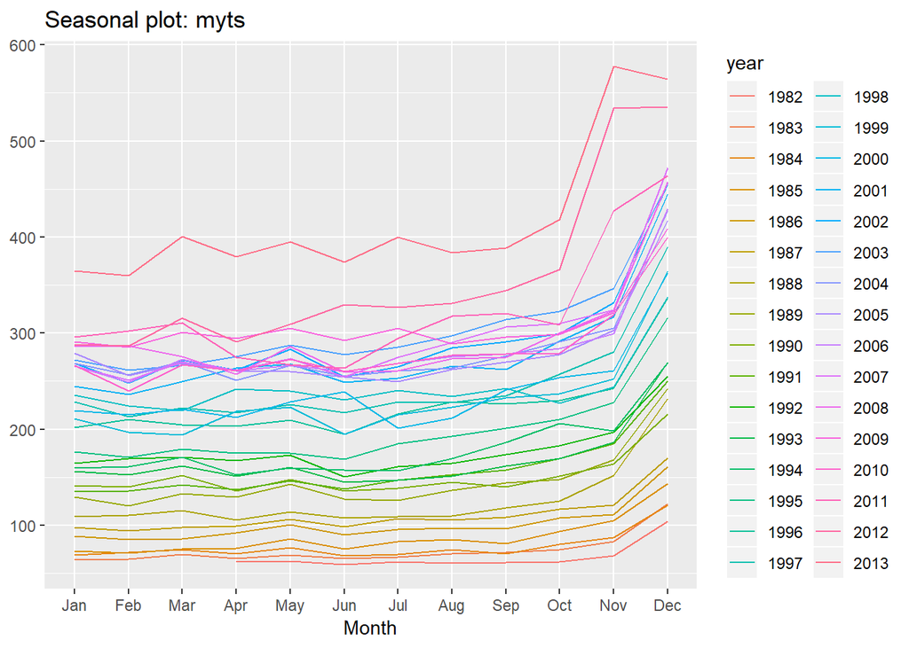

```r
ggseasonplot(myts)
```

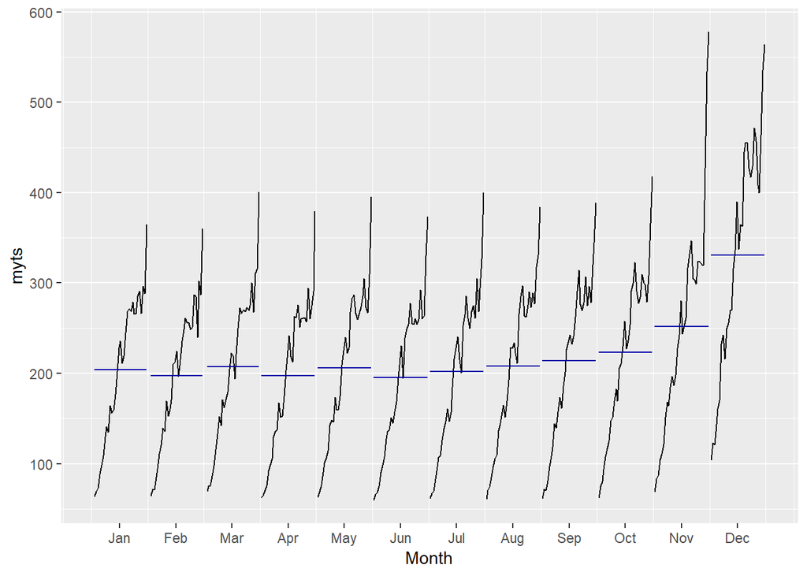

```r
ggsubseriesplot(myts)
```

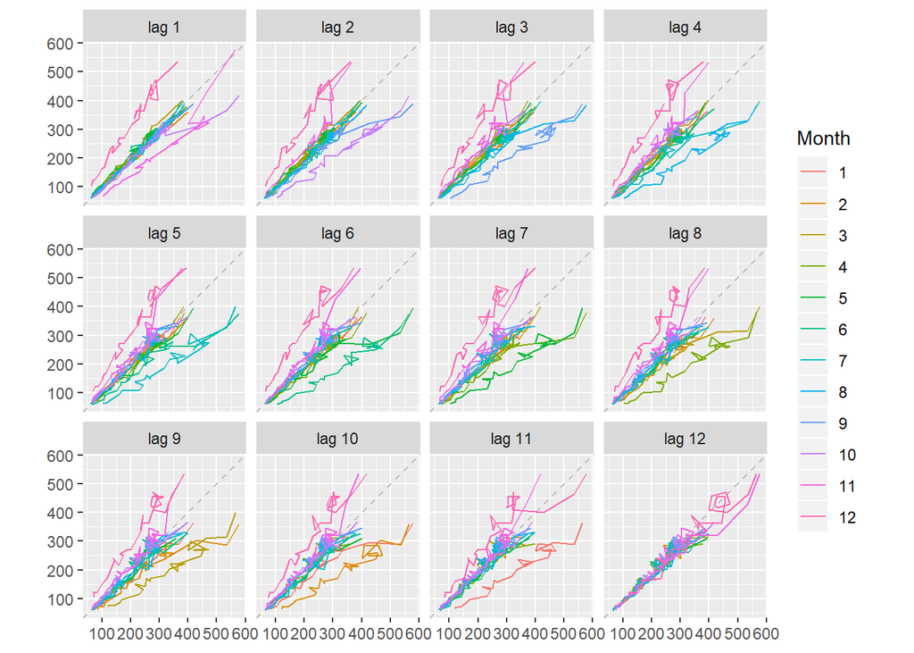

```r
gglagplot(myts, lags = 12)
```

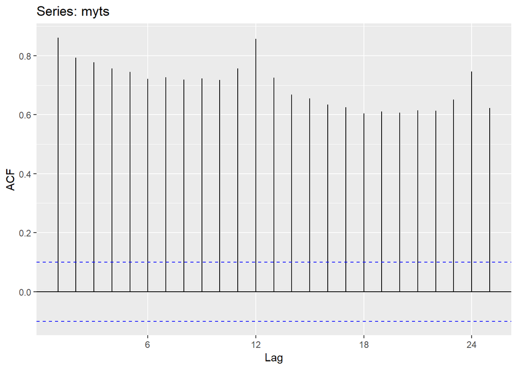

```r
ggAcf(myts)
```

```r
# Seasonality and trend of the data can be seen
```

4. Create time plots of the following times series: bicoal, chicken, dole, usdeaths, lynx, goog, writing, fancy, a10, h02.

```r
# - Use help() to find out about the data in each series.
help(bicoal)
```

```
## starting httpd help server ... done
```

```r
help(chicken)
help(dole)
help(usdeaths)
help(lynx)
help(goog)
help(writing)
help(fancy)
help(a10)
help(h02)
```

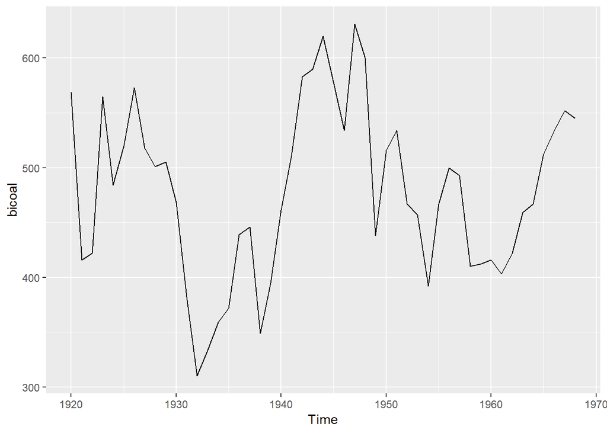

```r
autoplot(bicoal)
```

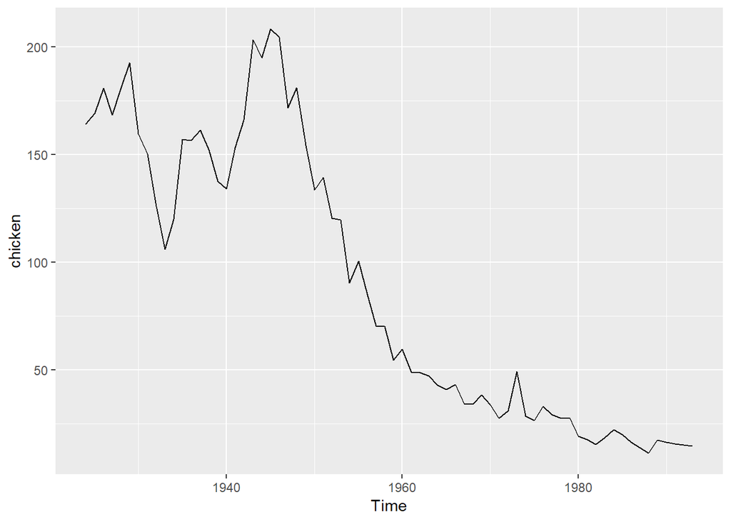

```r
autoplot(chicken)
```

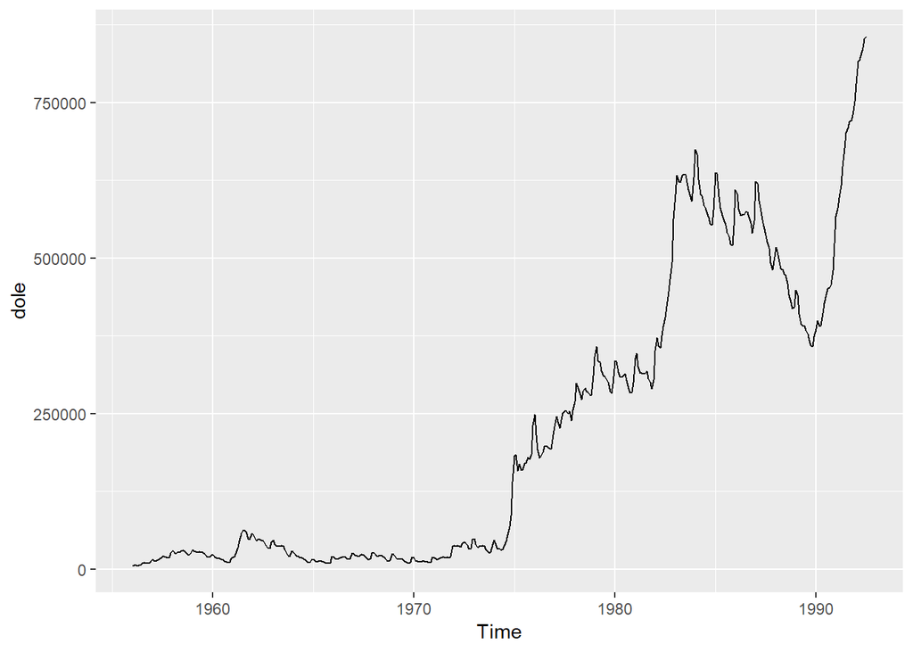

```r
autoplot(dole)
```

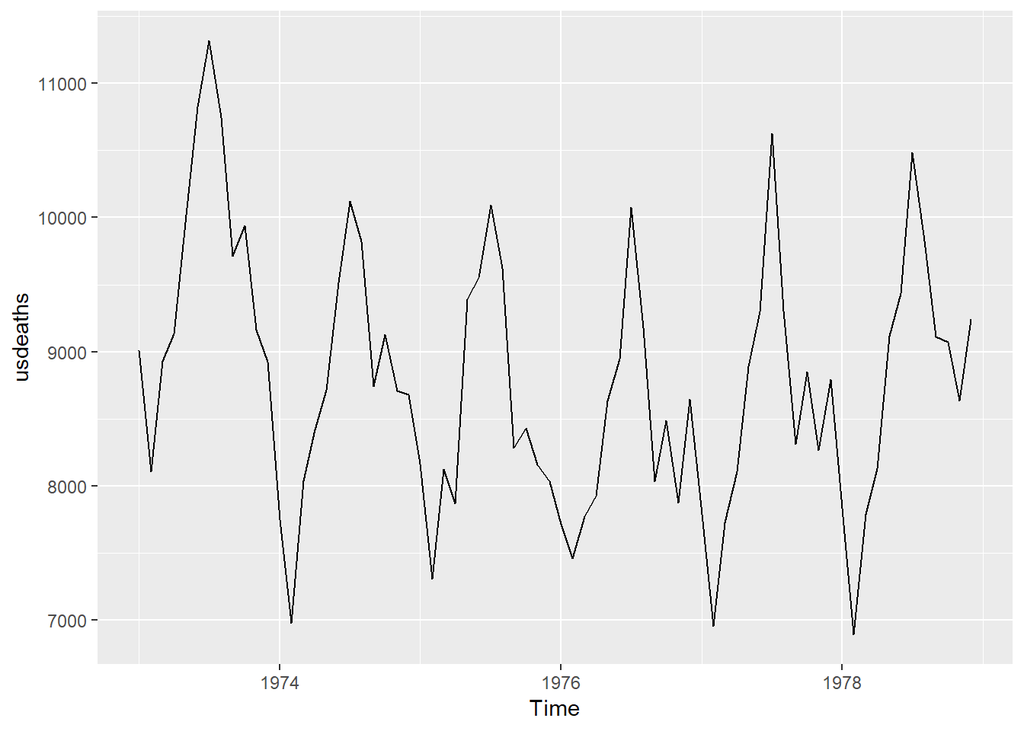

```r
autoplot(usdeaths)
```

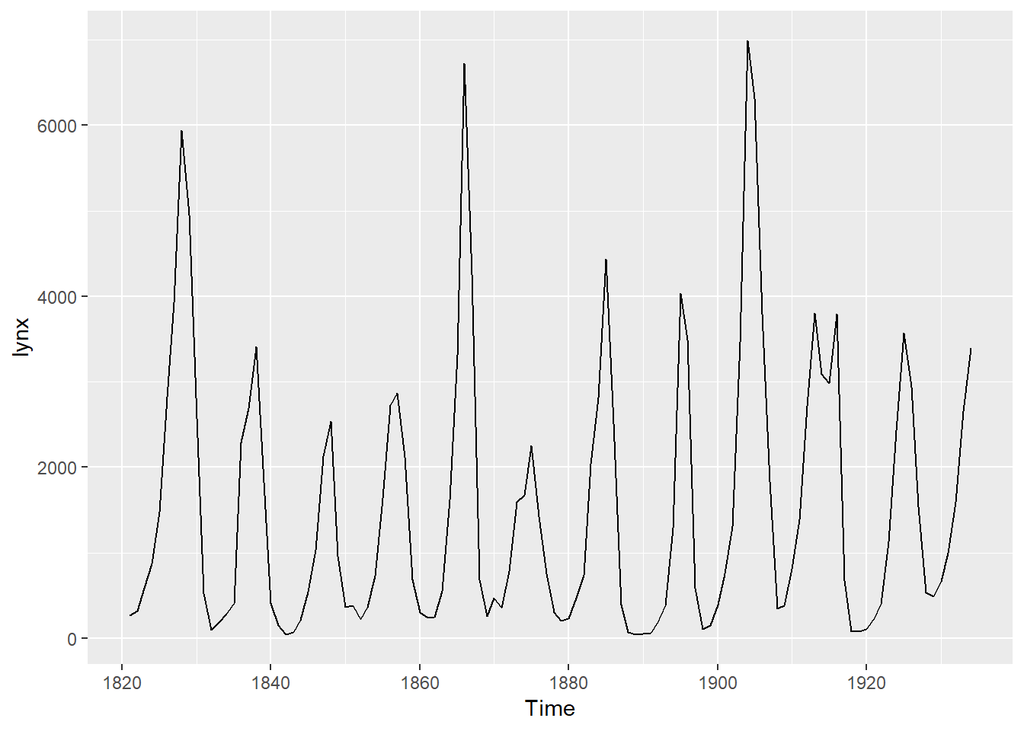

```r
autoplot(lynx)
```

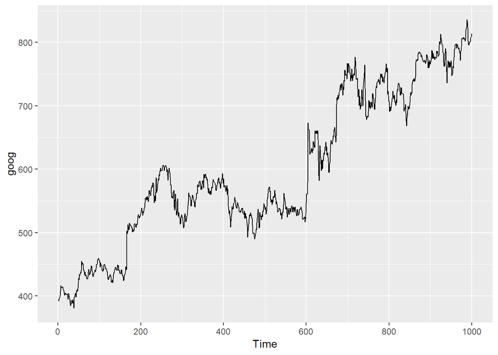

```r
autoplot(goog)
```

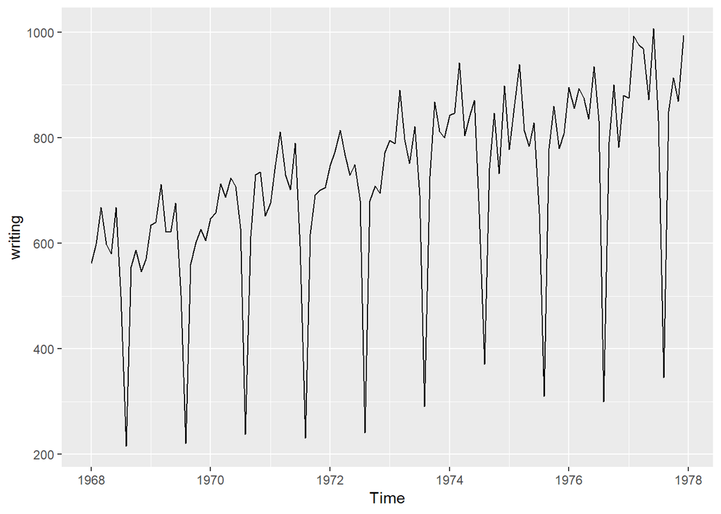

```r
autoplot(writing)
```

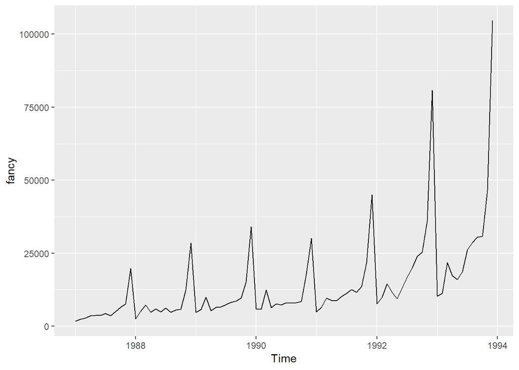

```r
autoplot(fancy)
```

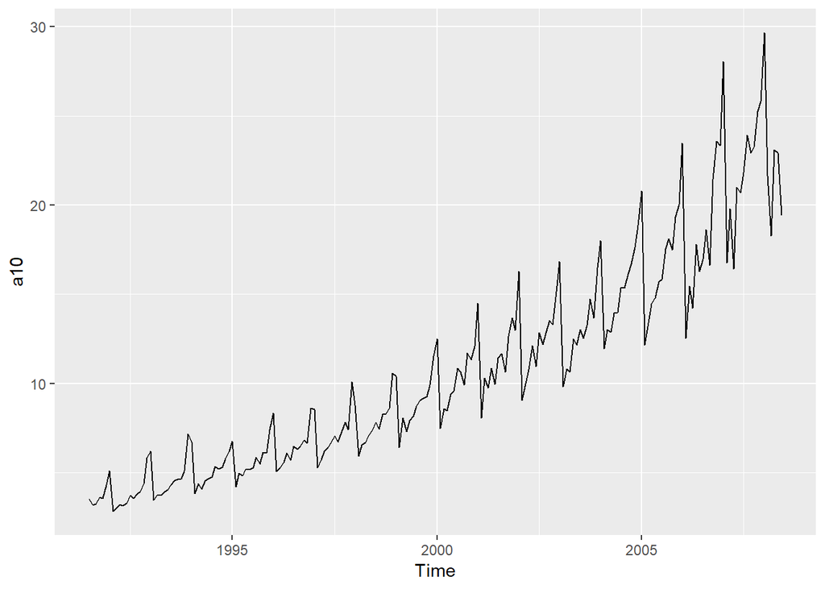

```r
autoplot(a10)
```

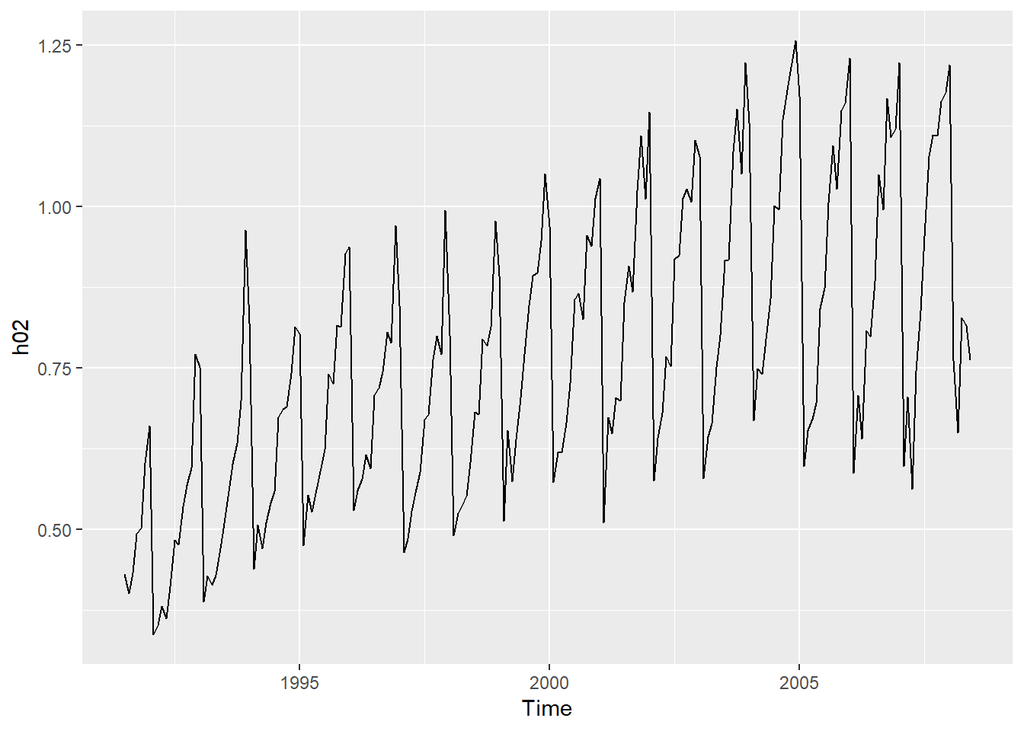

```r
autoplot(h02)
```

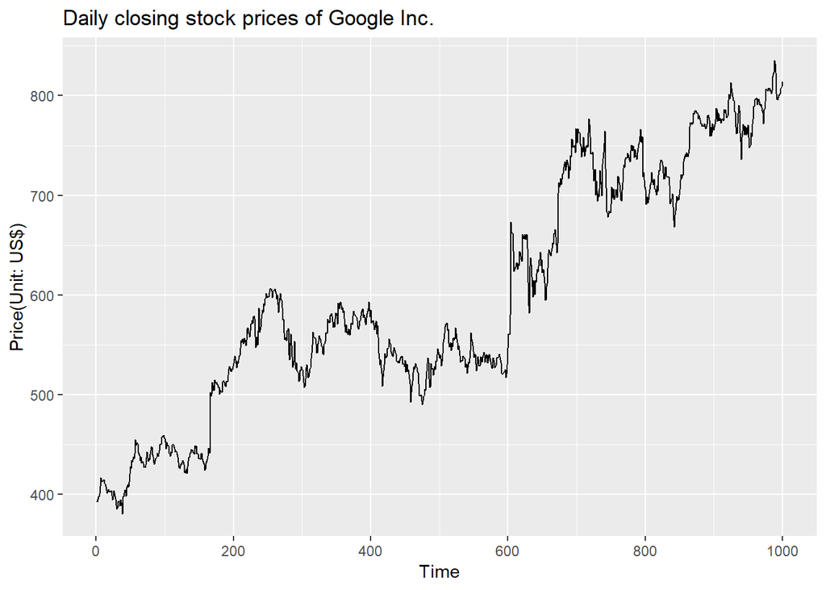

```r
# - For the goog plot, modify the axis labels and title.
autoplot(goog) +
  ggtitle("Daily closing stock prices of Google Inc.") +
  xlab("Time") +
  ylab("Price(Unit: US$)")
```

5. Use the ggseasonplot() and ggsubseriesplot() functions to explore the seasonal patterns in the following time series: writing, fancy, a10, h02.

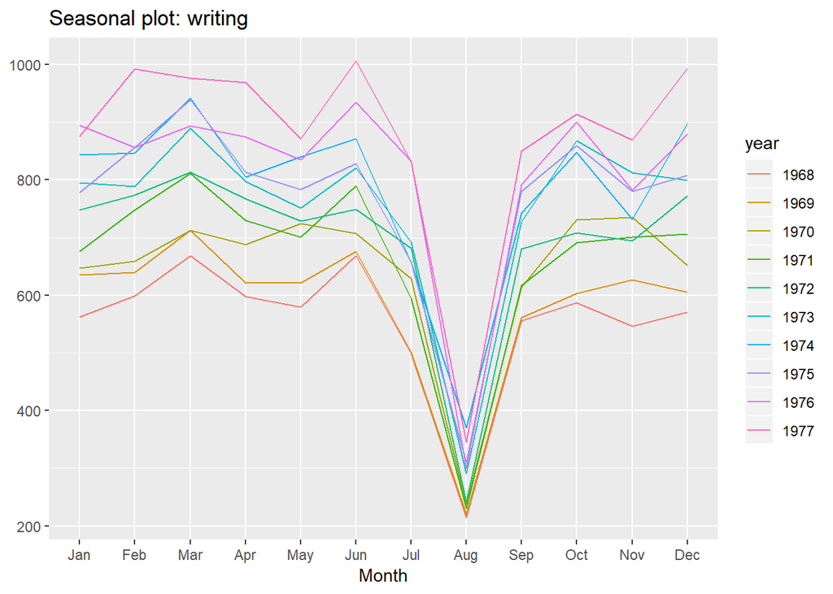

```r
# - What can you say about the seasonal patterns?
# - Can you identify any unusual years?
ggseasonplot(writing)
```

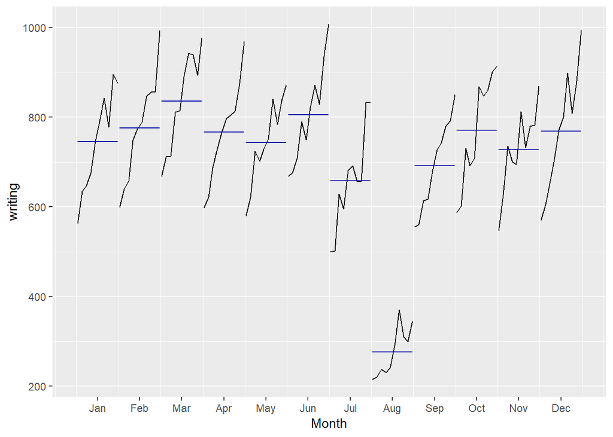

```r
ggsubseriesplot(writing)
```

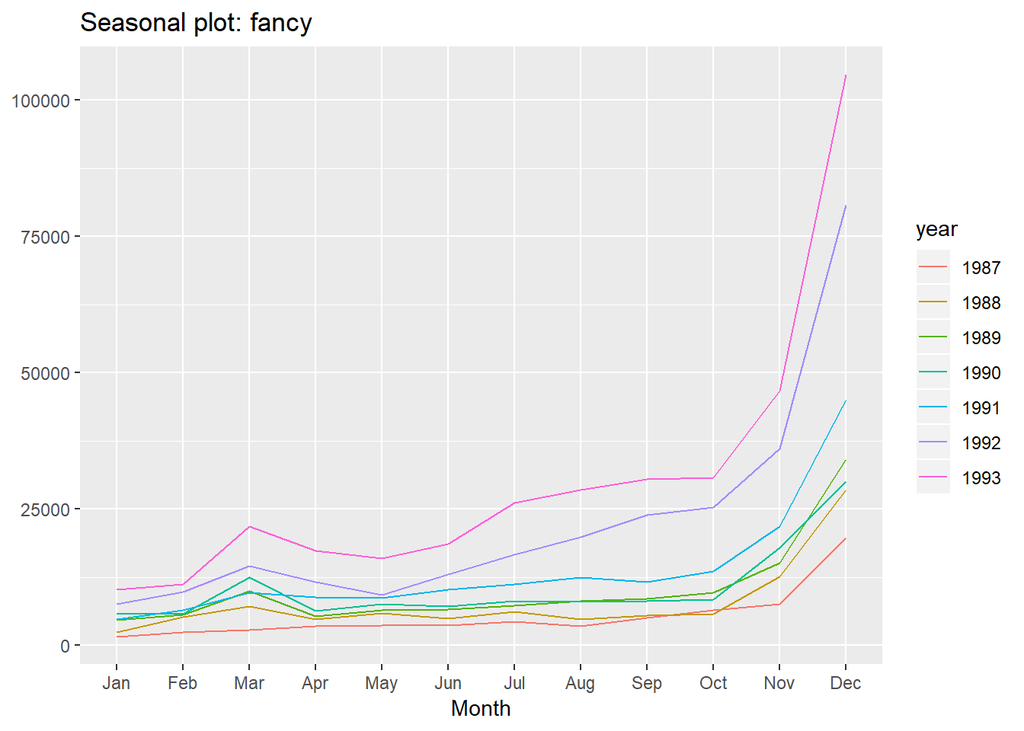

```r
# The sales amount of paper falls down in August annually
ggseasonplot(fancy)
```

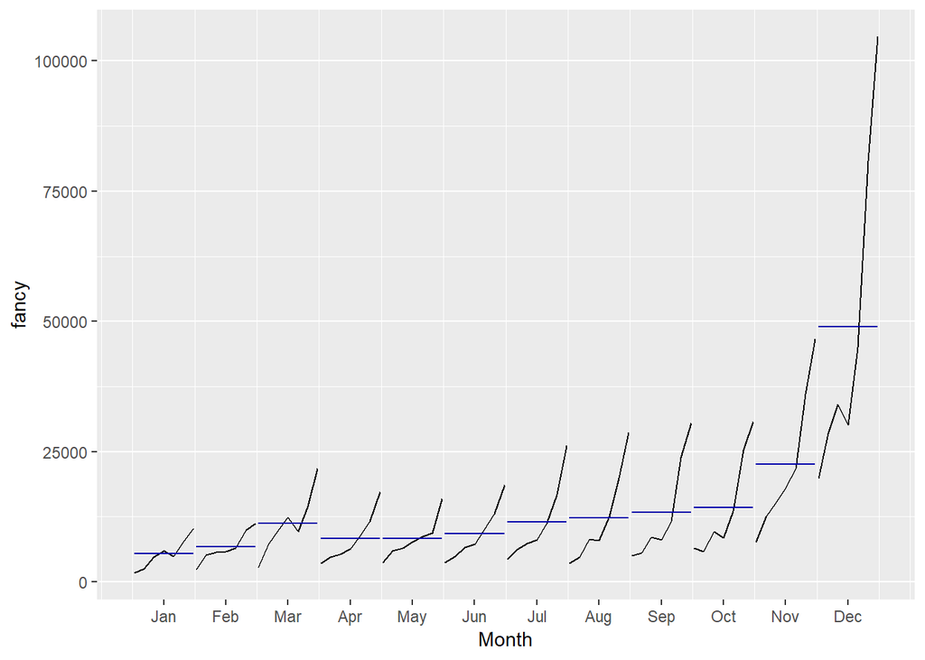

```r
ggsubseriesplot(fancy)
```

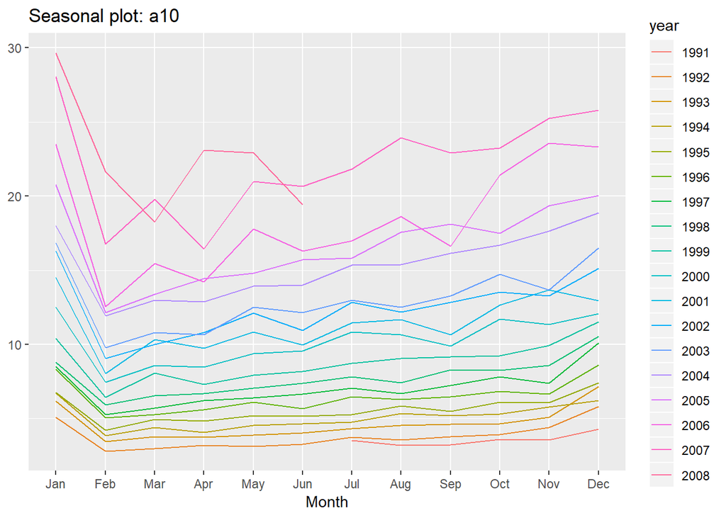

```r
# In December, 1992 the monthly sales for a souvenir shop increased dramatically compared to the same month of the last year
ggseasonplot(a10)
```

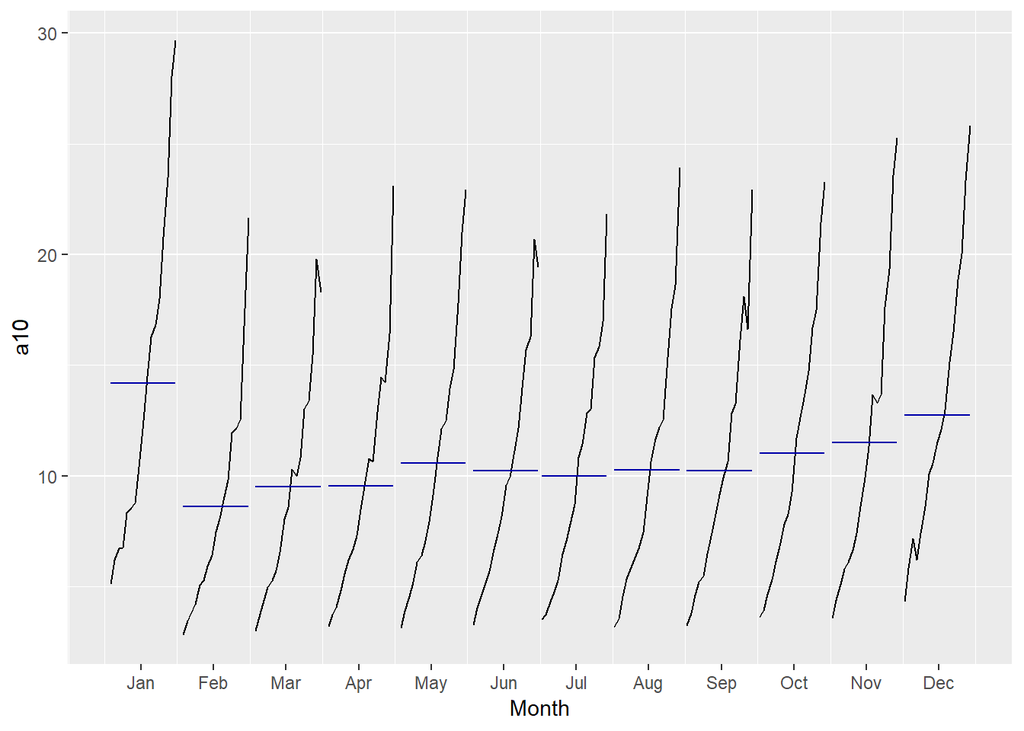

```r
ggsubseriesplot(a10)
```

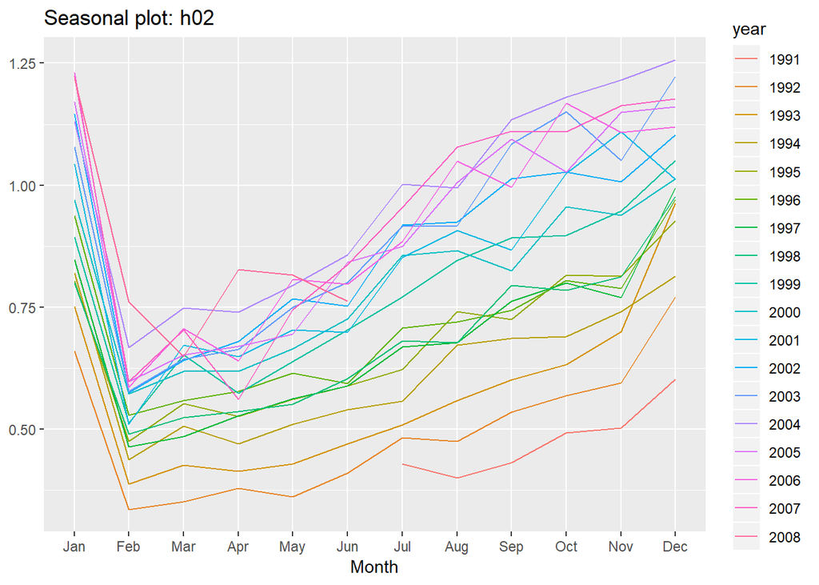

```r
# The amount of antidiabetes monthly scripts falls down in February annually
ggseasonplot(h02)
```

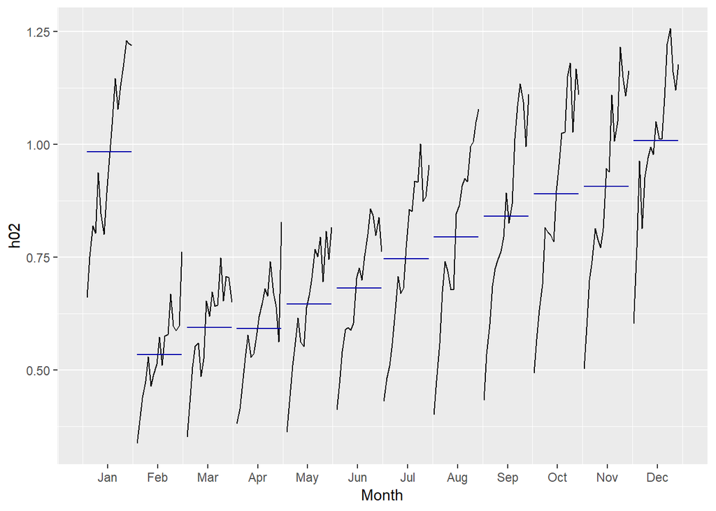

```r
ggsubseriesplot(h02)
```

```r
# The amount of corticosteroid monthly scripts also falls down in February annually
```

6. Use the the following graphics functions: autoplot, ggseasonplot, ggsubseriesplot, gglagplot, ggAcf and explore features from the following time series: hsales, usdeaths, bricksq, sunspotarea, gasoline.

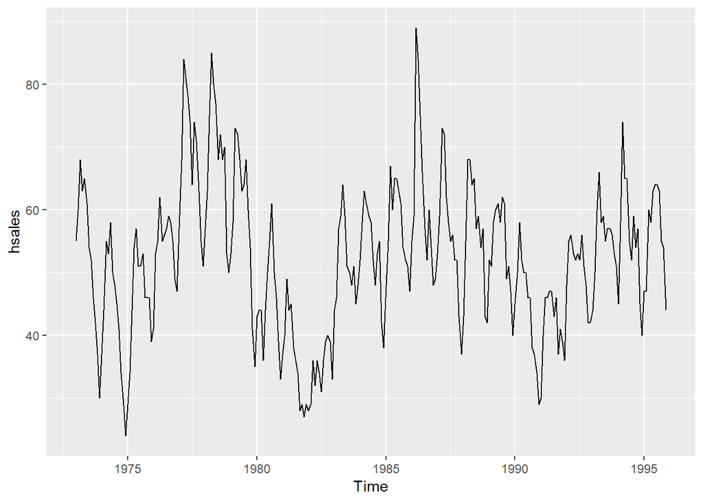

```r
# - Can you spot any seasonality, cyclicity and trend?
# - What do you learn about the series?
autoplot(hsales)
```